# Exercises STAT340 - Cluster analysis

Mar 10 2026

Make sure you have installed and loaded the following packages before you start with today’s exercises.

```r
library(tidyverse)
library(ggdendro)
library(ggdendro)
library(BIAS.data)
```

## 1 Exercise 1 - Bird presence & abundance in Norway

In the figure below, the observed mid-winter abundances of four different birds species have been marked with red colour (source: Jørgensen & Svorkmo-Lundberg (2006) Norsk vinterfuglatlas). Birds were observed in 10 km<sup>2</sup> squares accross entire mainland Norway, which was divided into 3163 squares in total. Every square is considered one variable. In this exercise, we will consider the 25 most abundant winter bird species in Norway, starting with the four displayed in the figure. In this exercise, we want to cluster birds into groups based on their geographical distribution during winter using hierarchical clustering methods. Which birds have similar distribution in Norway during winter?

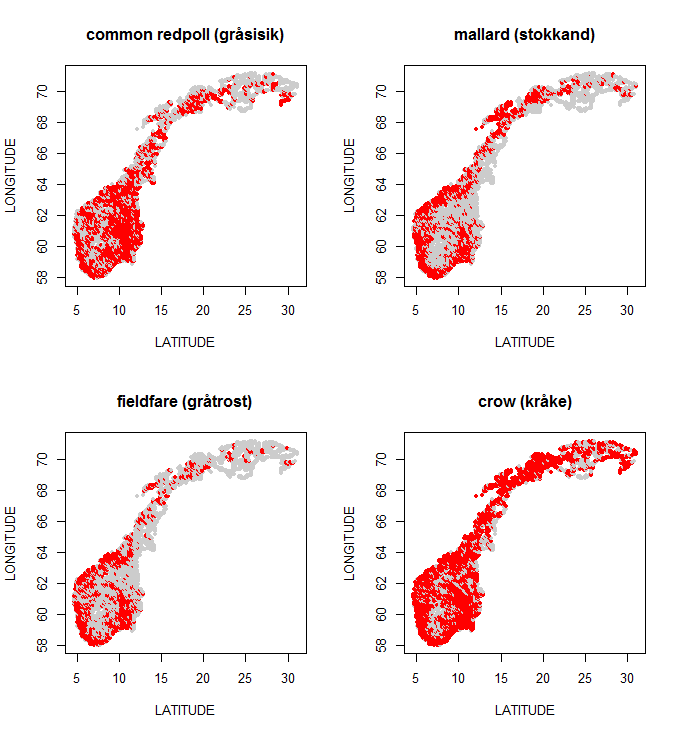

Fig. 1: Abundance of four common bird species in Norway during winter.

We will use data containing maximum abundance measures of each of 25 birds in the 3163 squares. The value reflects the largest simultaneous count of a given bird species in a square region.

1. Below there are three tables. In the table on top are the Euclidean distances between the abundance measures for the four species, A–D, shown in the figure above. The second table is the table after merging species C and D into the first cluster (called C/D). Use the single linkage method to fill in the missing distances in this table. Finally, there is a 2 × 2 table at the bottom for the second clustering iteration. Write down the table and fill in the missing “cluster names” (?/?) as well as the missing distances (`NA`).

   Before the 1<sup>st</sup> iteration:

|  | A | B | C | D |
| --- | --- | --- | --- | --- |
| A | 0.0 | 125.2 | 129.0 | 126.3 |
| B | 125.2 | 0.0 | 106.7 | 126.3 |
| C | 129.0 | 106.7 | 0.0 | 96.7 |
| D | 126.3 | 126.3 | 96.7 | 0.0 |

After the 1<sup>st</sup> iteration:

|  | A | B | C/D |
| --- | --- | --- | --- |
| A | NA | NA | NA |
| B | NA | NA | NA |
| C/D | NA | NA | NA |

After the 2<sup>nd</sup> iteration:

|  | ?/? | ?/? |
| --- | --- | --- |
| ?/? | NA | NA |
| ?/? | NA | NA |

**Solution**

After the 1<sup>st</sup> iteration:

|  | A | B | C/D |
| --- | --- | --- | --- |
| A | 0.0 | 125.2 | 126.3 |
| B | 125.2 | 0.0 | 106.7 |
| C/D | 126.3 | 106.7 | 0.0 |

After the 2<sup>nd</sup> iteration:

|  | A | B/C/D |
| --- | --- | --- |
| A | 0.0 | 125.2 |
| B/C/D | 125.2 | 0.0 |

2. Sketch the corresponding dendrogram for this hierachical clustering.

**Solution**

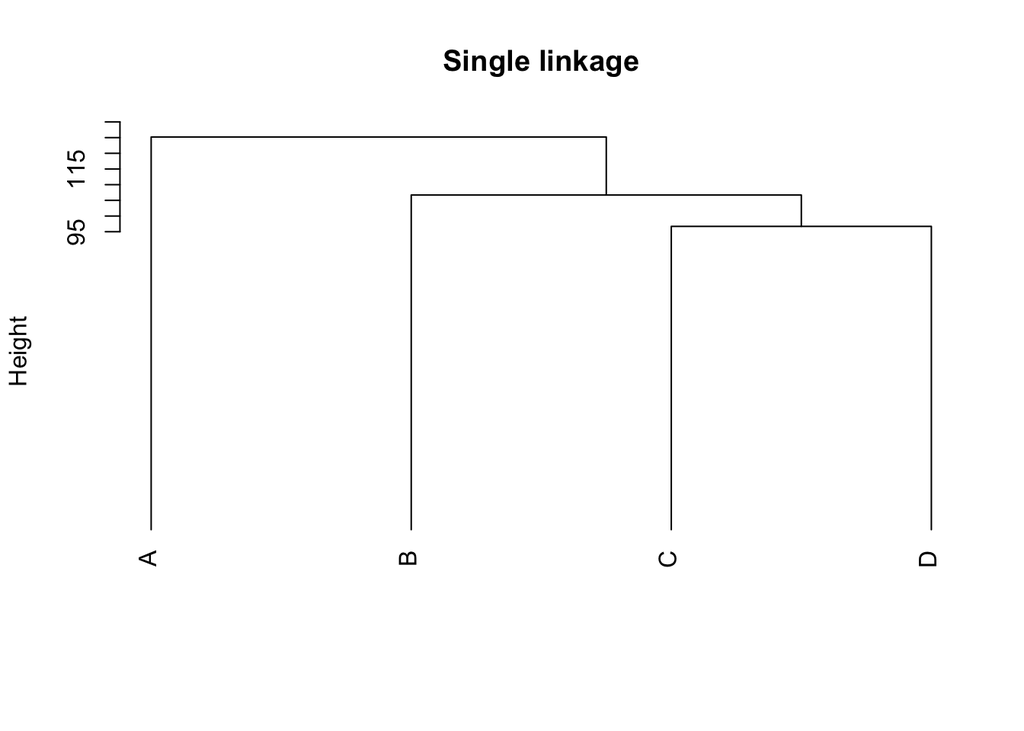

```r
d <- matrix(c(0, 125.2, 129.0, 126.3, 125.2, 0, 106.7, 126.3, 129.0, 106.7, 0, 96.7,
              126.3, 126.3, 96.7, 0), nrow = 4, ncol = 4, byrow = TRUE)
rownames(d) <- c("A", "B", "C", "D")
colnames(d) <- rownames(d)

clust <- hclust(as.dist(d), method = "single")
plot(clust, hang = -1, main = "Single linkage",xlab = "", sub = "")
```

3. Load the data for the four most common birds using `data(Birds4)` and run hierarchical clustering in RStudio with single linkage and Euclidean distances. Plot the dendrogram. This should yield the same dendrogram as the one you sketched in exercise b). Use the results from here to check your answer in exercise a).

**Solution**

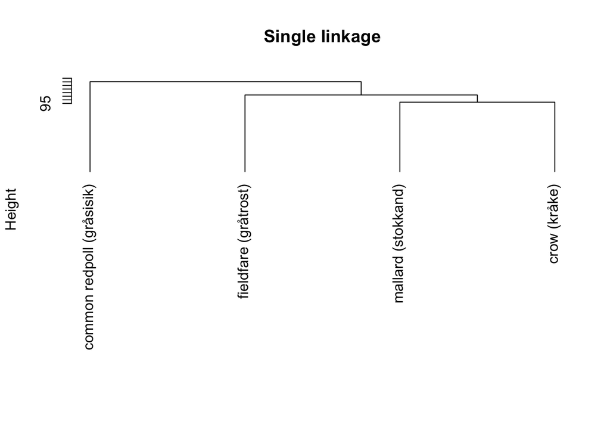

```r
data(Birds4)

edistBirds4 <- dist(Birds4, method = "euclidean")     # calculating an Euclidean distance matrix
clustBirds4 <- hclust(edistBirds4, method = "single") # hierachical clustering with single linkage

# Plot dendrogram using the base R package
plot(clustBirds4, hang = -1, main = "Single linkage", xlab = "", sub = "")
```

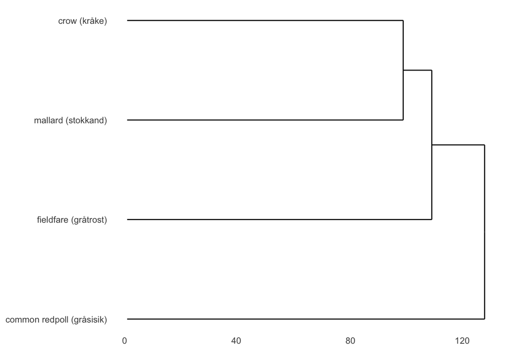

```r
# Plot dendrogram using the ggdendro package
ggdendrogram(clustBirds4, rotate = TRUE)
```

- The distance matrix `round(edistBirds4, digits = 1)` is equivalent to the table that you started with (before the first iteration).
- The distances between the clusters are stored in the `height` element of the dendrogram. You can retrieve it with the command `round(clustBirds4$height, digits = 1)`.

Here’s how to check your answers in a):

```r
round(clustBirds4$height, digits = 1)
```

```
## [1]  96.7 106.7 125.2
```

**Solution**

Creating the distance matrix with `dist`

```r
edistBirds <- dist(Birds, method = "euclidean")
```

We will plot with `ggdendro`, which allows us to rotate the dendrogram and thus make it more reader-friendly.

Single linkage:

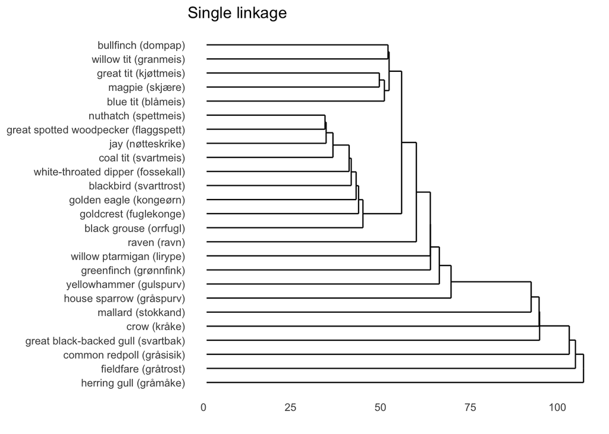

```r
clustBirds.sin <- hclust(edistBirds, method = "single")

ggdendrogram(clustBirds.sin, rotate = TRUE) + ggtitle("Single linkage")
```

Complete linkage:

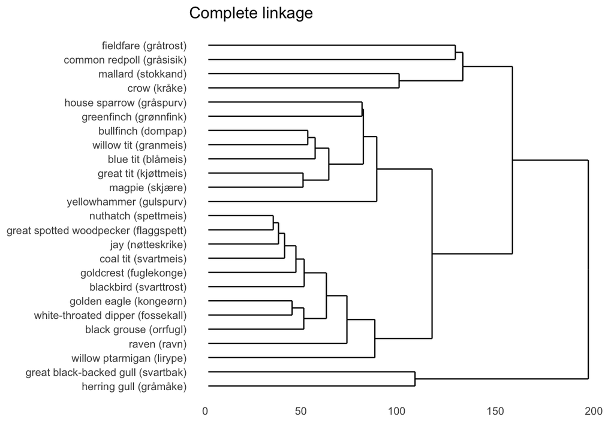

```r
clustBirds.com <- hclust(edistBirds, method = "complete")

ggdendrogram(clustBirds.com, rotate = TRUE) + ggtitle("Complete linkage")
```

Average linkage:

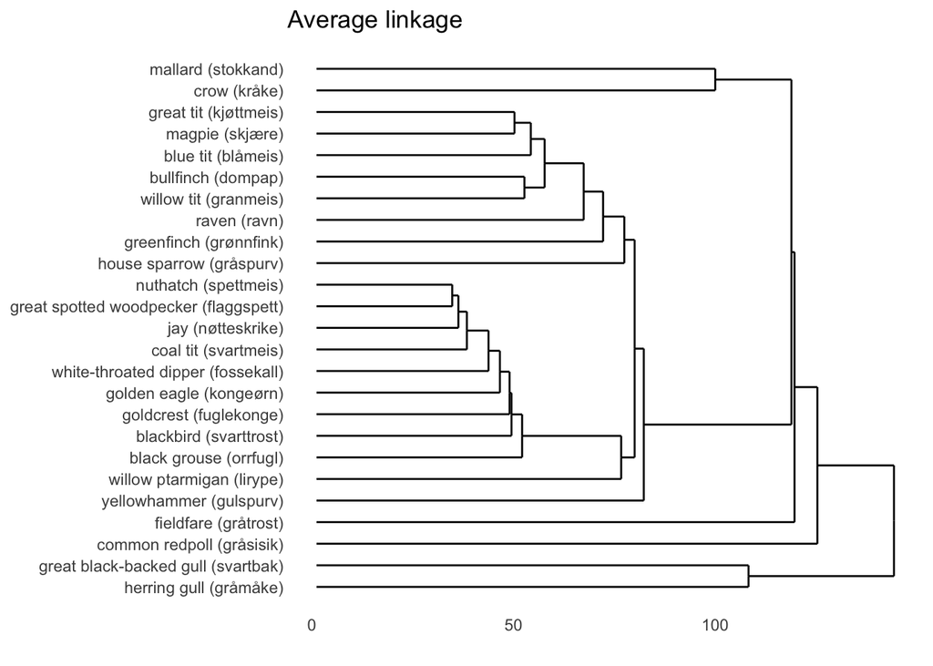

```r
clustBirds.avg <- hclust(edistBirds, method = "average")

ggdendrogram(clustBirds.avg, rotate = TRUE) + ggtitle("Average linkage")
```

5. Repeat exercise d) with average linkage, but change the distance method from Euclidean to Manhattan. Compare the two average linkage dendrograms. Does the grouping change much?

**Solution**

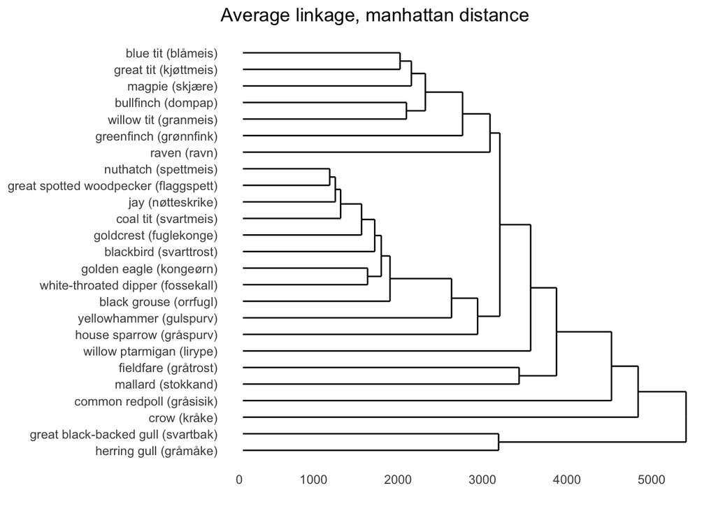

```r
# Computing a Manhattan distance matrix.
mdistBirds <- dist(Birds, method = "manhattan")

# Hierachical clustering with average linkage.
clustBirds.avg.m <- hclust(mdistBirds, method = "average")

# Plot the plot!
ggdendrogram(clustBirds.avg.m, rotate = TRUE) + ggtitle("Average linkage, manhattan distance")
```

6. Let’s return to the research question: which birds have similar distribution in Norway during winter? How does your answer depend on linkage method and distance measure?

**Solution**

The answer depends on the distance measure and linkage method…

7. You can read about other distance measures in the help file for distance measures in `R`. Write `?dist` in the console window and press enter. For instance, under **Details** you can read about “binary” distance. Use the code below to compute a binary distance matrix and plot the dendrogram with average linkage.

What do you think, does binary distance measure *abundance* or *occurrence* distances between the birds?

```r
bdistBirds <- dist(Birds, method = "binary") # changing this to compute a binary distance matrix

clustBirds.avg.b <- hclust(bdistBirds, method = "average") %>%
   ggdendrogram(rotate = TRUE) + ggtitle("Binary distance & average linkage")

clustBirds.avg.b
```

[output not shown]

**Solution**

It measures occurrence.

Under “Details” in `?dist`, the following is written about binary distance:

“The vectors are regarded as binary bits, so non-zero elements are ‘on’ and zero elements are ‘off’. The distance is the proportion of bits in which only one is on amongst those in which at least one is on”.

We need only distinguish the zero-values from the non-zero in our dataset. We will illustrate this with a simple example. Let’s say we are checking if two species of birds is present on 4 different sites.

Below there is one site where at least one is ‘on’, meaning at least one bird species is present. For this site both are `on` (both species are present at the same site). Therefore the distance is 0:

```r
foo <- rbind(c(0,1,0,0), c(0,1,0,0))
rownames(foo) <- c("Species A", "Species B")
colnames(foo) <- c("Site A", "Site B", "Site C", "Site D")
print(foo)
```

```
##           Site A Site B Site C Site D
## Species A      0      1      0      0
## Species B      0      1      0      0
```

```r
dist(foo, method = "binary")
```

```
##           Species A
## Species B         0
```

Below there are two sites where at least one is `on`. In one of these, only one is `on`. Therefore the distance is 0.5:

```r
foo <- rbind(c(1,0,0,0), c(1,1,0,0))
rownames(foo) <- c("Species A", "Species B")
colnames(foo) <- c("Site A", "Site B", "Site C", "Site D")
print(foo)
```

```
##           Site A Site B Site C Site D
## Species A      1      0      0      0
## Species B      1      1      0      0
```

```r
dist(foo, method = "binary")
```

```
##           Species A
## Species B       0.5
```

If the two species cannot tolerate one another, we get a maximal distance of 1:

```r
foo <- rbind(c(1,1,0,0), c(0,0,1,1))
rownames(foo) <- c("Species A", "Species B")
colnames(foo) <- c("Site A", "Site B", "Site C", "Site D")
print(foo)
```

```
##           Site A Site B Site C Site D
## Species A      1      1      0      0
## Species B      0      0      1      1
```

```r
dist(foo, method = "binary")
```

```
##           Species A
## Species B         1
```

Even if we are counting the *number of birds* on each island, instead of simply checking if it is there or not, the answer remains unchanged. This is because we are comparing zero-values to non-zero-values:

```r
foo <- rbind(c(14,6,0,0), c(0,0,86,49))
rownames(foo) <- c("Species A", "Species B")
colnames(foo) <- c("Site A", "Site B", "Site C", "Site D")
print(foo)
```

```
##           Site A Site B Site C Site D
## Species A     14      6      0      0
## Species B      0      0     86     49
```

```r
dist(foo, method = "binary")
```

```
##           Species A
## Species B         1
```

Let us return to the winterbirds data, and calculate the binary distance between 4 of the bird species:

```r
dist(Birds4, method="binary")
```

```
##                      common redpoll (gråsisik) fieldfare (gråtrost)
## fieldfare (gråtrost)                 0.5100935
## mallard (stokkand)                   0.5508820            0.4443092
## crow (kråke)                         0.3832886            0.5308642
##                      mallard (stokkand)
## fieldfare (gråtrost)
## mallard (stokkand)
## crow (kråke)                  0.4557066
```

Binary distance will always have a value of between 0 and 1, and is a measure of occurrence between bird species. For instance, crow and redpoll are the closest species in binary distance. This means that the occurrence pattern of crow is more similar to the occurrence pattern of common redpoll compared to any of the other 2 species.